# Predicting Wildfire Incidence in the United States

Rohit Krishna

## 1 Abstract

In this paper, the problem of predicting wildfires is modeled as a binary classification problem with spatial and temporal characteristics. Specifically, a notable wildfire is defined as a wildfire with a final burned area of at least 300 acres. The modeling unit is defined as the state-month, and the binary classification is defined as 1 if a state has at least one notable wildfire in a month and 0 otherwise. In addition, the performance of the logistic regression model is compared with a random forest model with lagged wildfire history and seasonal predictors. The performance of the two models is assessed using time-aware validation with Area Under the ROC Curve (AUC). The results demonstrate that the random forest model has stronger out-of-sample discrimination ability, whereas the logistic regression model is simpler and more interpretable.

## 2 Introduction

Wildfire is a critical environmental hazard in the United States, which has been escalating over the years in terms of frequency and intensity. The understanding of the various aspects of wildland fire incidence helps in the prediction of such occurrences, which in turn helps in controlling them. In this report, we aim to study the wildland fire incidence in the United States, followed by the creation of a model to predict the wildland fire incidence in the country.

## 3 Data Preprocessing

In this section, I convert the wildfire data into a panel format for binary classification. As recommended in the project setup, a wildfire is considered notable if its size is at least 300 acres. In this case, for each state and month, my response variable takes a value of 1 if at least one notable wildfire occurs in a given month, otherwise 0. My predictors include lagged wildfire variables, lagged counts, rolling counts, historical rates, and seasonal variables. I make sure that all combinations of states and months are filled in so that months without a wildfire can be identified by a response variable of 0.

```r
wildfires <- read_csv("wildfires_sample_100k.csv", show_col_types = FALSE) %>%
  clean_names()

glimpse(wildfires)
```

```
## Rows: 100,000
## Columns: 39
## $ objectid                   <dbl> 16, 68, 73, 111, 191, 228, 264, 269, 294, 3…
## $ fod_id                     <dbl> 16, 68, 74, 112, 194, 231, 268, 274, 299, 3…
## $ fpa_id                     <chr> "FS-1418876", "FS-1419017", "FS-1419045", "…
## $ source_system_type         <chr> "FED", "FED", "FED", "FED", "FED", "FED", "…
## $ source_system              <chr> "FS-FIRESTAT", "FS-FIRESTAT", "FS-FIRESTAT"…
## $ nwcg_reporting_agency      <chr> "FS", "FS", "FS", "FS", "FS", "FS", "FS", "…
## $ nwcg_reporting_unit_id     <chr> "USCAENF", "USMTKNF", "USMTKNF", "USCASNF",…
## $ nwcg_reporting_unit_name   <chr> "Eldorado National Forest", "Kootenai Natio…
## $ source_reporting_unit      <chr> "0503", "0114", "0114", "0515", "0302", "03…
## $ source_reporting_unit_name <chr> "Eldorado National Forest", "Kootenai Natio…
## $ local_fire_report_id       <chr> "103", "43", "33", "2", "279", "16", "37", …
## $ local_incident_id          <chr> "22", "015", "008", "01", "279", "06", "014…
## $ fire_code                  <chr> NA, "BYE5", "BXR5", "BGJ2", "F279", "BEX6",…
```

[output cut: 26 more lines]

```r
notable_cutoff <- 300

wildfires2 <- wildfires %>%
  mutate(
    discovery_date_num = as.numeric(discovery_date),
    cont_date_num = as.numeric(cont_date),
    discovery_date_clean = as.Date(discovery_date_num - 2415018.5, origin = "1899-12-30"),
    cont_date_clean = as.Date(cont_date_num - 2415018.5, origin = "1899-12-30"),
    month_date = floor_date(discovery_date_clean, unit = "month"),
    month = month(month_date),
    year = year(month_date),
    notable_fire = if_else(fire_size >= notable_cutoff, 1L, 0L),
    lightning_fire = if_else(stat_cause_descr == "Lightning", 1L, 0L)
  ) %>%
  filter(!is.na(state), !is.na(month_date), !is.na(year), !is.na(month))

state_month_raw <- wildfires2 %>%
  group_by(state, month_date, year, month) %>%
  summarise(
    any_notable = as.integer(any(notable_fire == 1)),
    notable_count = sum(notable_fire, na.rm = TRUE),
    total_fires = n(),
    avg_fire_size = mean(fire_size, na.rm = TRUE),
    max_fire_size = max(fire_size, na.rm = TRUE),
    lightning_share = mean(lightning_fire, na.rm = TRUE),
    .groups = "drop"
  )

all_states <- sort(unique(wildfires2$state))
all_months <- seq(min(state_month_raw$month_date), max(state_month_raw$month_date), by = "month")

state_month <- expand_grid(
  state = all_states,
  month_date = all_months
) %>%
  mutate(
    year = year(month_date),
    month = month(month_date)
  ) %>%
  left_join(state_month_raw, by = c("state", "month_date", "year", "month")) %>%
  mutate(
    any_notable = replace_na(any_notable, 0L),
    notable_count = replace_na(notable_count, 0),
    total_fires = replace_na(total_fires, 0),
    avg_fire_size = replace_na(avg_fire_size, 0),
    max_fire_size = replace_na(max_fire_size, 0),
    lightning_share = replace_na(lightning_share, 0)
  ) %>%
  arrange(state, month_date) %>%
  group_by(state) %>%
  mutate(
    lag_any_1 = lag(any_notable, 1),
    lag_any_2 = lag(any_notable, 2),
    lag_any_3 = lag(any_notable, 3),
    lag_any_12 = lag(any_notable, 12),
    lag_notable_1 = lag(notable_count, 1),
    lag_notable_12 = lag(notable_count, 12),
    lag_total_1 = lag(total_fires, 1),
    lag_total_12 = lag(total_fires, 12),
    lag_lightning_share_1 = lag(lightning_share, 1),
    roll_notable_3 = slide_dbl(lag(notable_count, 1), ~sum(.x, na.rm = TRUE), .before = 2, .complete = TRUE),
    roll_notable_12 = slide_dbl(lag(notable_count, 1), ~sum(.x, na.rm = TRUE), .before = 11, .complete = TRUE),
    cum_notable_prior = lag(cumsum(notable_count), 1),
    month_index = row_number(),
    hist_rate = if_else(month_index > 1, cum_notable_prior / (month_index - 1), NA_real_),
    month_sin = sin(2 * pi * month / 12),
    month_cos = cos(2 * pi * month / 12)
  ) %>%
  ungroup()

model_df <- state_month %>%
  filter(!is.na(lag_any_12), !is.na(roll_notable_12), !is.na(hist_rate))

summary_tbl <- tibble(
  Metric = c(
    "Notable-fire cutoff (acres)",
    "Spatial unit",
    "Temporal unit",
    "Number of states",
    "Years covered",
    "Number of state-month rows",
    "Positive state-months",
    "Positive rate",
    "Predictors"
  ),
  Value = c(
    notable_cutoff,
    "State",
    "Month",
    n_distinct(model_df$state),
    paste0(min(model_df$year), " - ", max(model_df$year)),
    nrow(model_df),
    sum(model_df$any_notable),
    round(mean(model_df$any_notable), 3),
    "Lagged wildfire indicators, lagged counts, rolling counts, lightning share, historical rate, seasonal terms"
  )
)

kable(summary_tbl, caption = "Summary of final modeling dataset", booktabs = TRUE) %>%
  kable_styling(full_width = FALSE, bootstrap_options = c("striped", "hover", "condensed"))
```

Summary of final modeling dataset

| Metric | Value |
| --- | --- |
| Notable-fire cutoff (acres) | 300 |
| Spatial unit | State |
| Temporal unit | Month |
| Number of states | 52 |
| Years covered | 1993 - 2015 |
| Number of state-month rows | 14352 |
| Positive state-months | 888 |
| Positive rate | 0.062 |
| Predictors | Lagged wildfire indicators, lagged counts, rolling counts, lightning share, historical rate, seasonal terms |

## 4 Exploratory Data Analysis

This section determines the primary spatial and temporal trends in the wildfire data and relate this to the modeling choices. The following plots show the variability in the number of wildfires by state and the seasonality in the data. This supports the use of historical risk measures specific to location and season in the modeling.

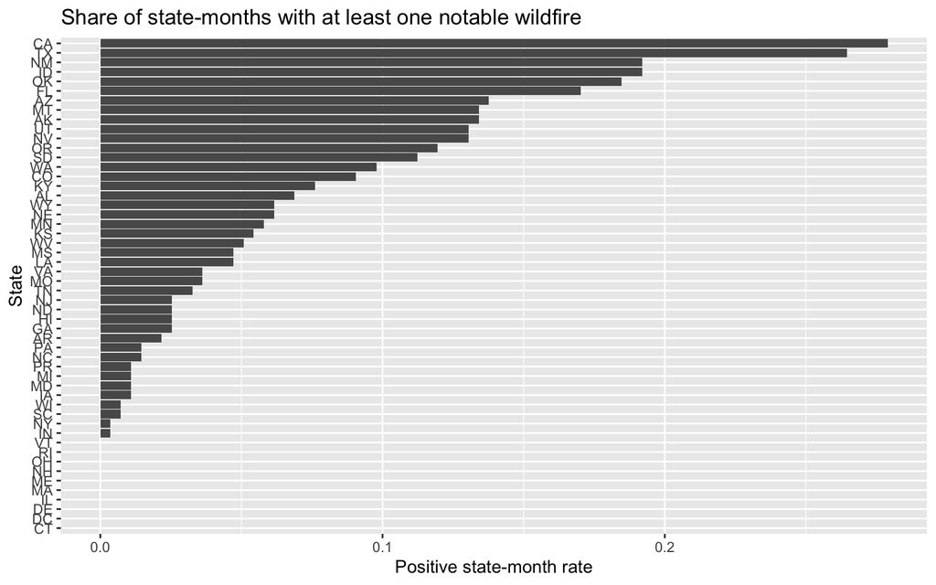

```r
state_incidence <- model_df %>%
  group_by(state) %>%
  summarise(positive_rate = mean(any_notable), .groups = "drop") %>%
  arrange(desc(positive_rate))

ggplot(state_incidence, aes(x = reorder(state, positive_rate), y = positive_rate)) +
  geom_col() +
  coord_flip() +
  labs(
    title = "Share of state-months with at least one notable wildfire",
    x = "State",
    y = "Positive state-month rate"
  )
```

The state-level incidence plot indicates a large variation in wildfire occurrence across the United States. Some states have a large number of wildfire-positive months, while others have relatively fewer. This variation indicates that wildfire occurrence is not uniformly distributed across the United States. This result makes sense when considering the differences in climate, vegetation, and background fire conditions. States with a relatively warmer and drier environment, along with fire-prone vegetation, will tend to have more wildfire-positive months. This result is important for the modeling stage, as it indicates that previous location-specific wildfire patterns will be a valuable source of information for prediction. This is because a model that ignores this variation will be neglecting an important source of variation.

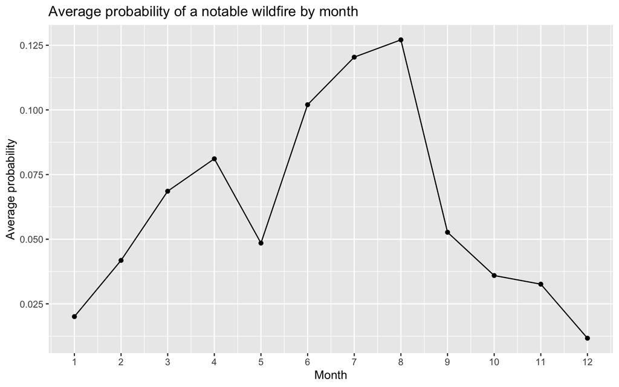

```r
monthly_seasonality <- model_df %>%
  group_by(month) %>%
  summarise(avg_prob = mean(any_notable), .groups = "drop")

ggplot(monthly_seasonality, aes(x = month, y = avg_prob)) +
  geom_line() +
  geom_point() +
  scale_x_continuous(breaks = 1:12) +
  labs(
    title = "Average probability of a notable wildfire by month",
    x = "Month",
    y = "Average probability"
  )
```

Moreover, the monthly trend plot above depicts that the seasonality of the incidence of wildfires is high. There is a high probability of a notable wildfire happening during the warmer months compared to the colder months. This is consistent with the environmental conditions that favor the incidence of wildfires. Hot temperatures, dry conditions, and low humidity that prevail during the summer season favor the incidence of wildfires. Conversely, the cool and wet conditions that prevail during the winter season hinder the incidence of wildfires. Therefore, the presence of seasonality in the incidence of wildfires is high, which suggests that the month-to-month risk of wildfires is not random. Instead, it is seasonal. Therefore, the presence of seasonality necessitates the use of seasonal variables in the modeling process. A good model that takes into consideration the seasonality of the incidence of wildfires is one that will be able to distinguish the high-risk months from the low-risk months.

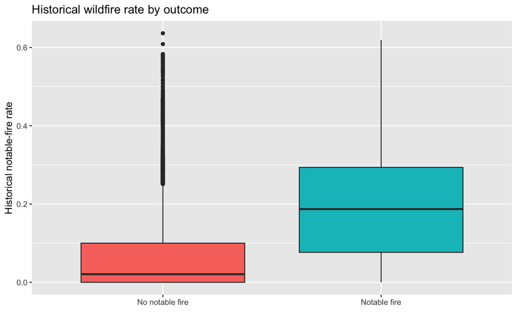

```r
model_df %>%
  mutate(outcome = factor(any_notable, levels = c(0, 1), labels = c("No notable fire", "Notable fire"))) %>%
  ggplot(aes(x = outcome, y = hist_rate, fill = outcome)) +
  geom_boxplot(show.legend = FALSE) +
  labs(
    title = "Historical wildfire rate by outcome",
    x = "",
    y = "Historical notable-fire rate"
  )
```

In the box plot showing the historical wildfire rate by outcome, it can be seen that state-months with notable wildfire incidence tend to have higher historical rates than state-months without notable wildfire incidence. This implies that state-months with higher historical wildfire activity are more likely to experience future wildfire occurrence. This result gives direct empirical support to the inclusion of lagged/cumulative wildfire history variables in the predictive models. More broadly, this result implies that there is a significant temporal persistence component to wildfire incidence: past activity contains relevant information for future risk. This is precisely the kind of structure that can be exploited by the predictive models, particularly when historical variables are combined with seasonality and lightning-related variables.

## 5 Modeling

The two models used in this report are logistic regression and random forest. The logistic regression is the base model in this report. The logistic regression is a basic model that is easy to understand and is appropriate for the problem. The logistic regression estimates the probability of a state-month having at least one notable wildfire based on historical wildfire activity, lightning-related information, and seasonal effects. The coefficients of the logistic regression are interpretable, making it a good benchmark for understanding how the wildfire risk varies with the predictor.

The second model is the random forest. This model is used because it is believed that the occurrence of wildfires is influenced by nonlinear relationships and interactions between predictors. For example, the effect of recent wildfire history could be nonlinear in that it depends on the season, and the effect of lightning-related risk could be nonlinear in that it depends on historical fire patterns. The performance of the models is assessed based on the area under the ROC curve (AUC) and how well each model separates state-months where there is significant wildfire incidence and those where there is not. The AUC values will be used to determine whether the increased flexibility of the random forest model, over the logistic regression model, makes it perform better.

$$\text{logit}\big(P(Y_{s,t}=1)\big)=\beta_0+\mathbf{x}_{s,t}^{\top}\boldsymbol{\beta}$$

where $Y_{s,t}$ is a binary variable indicating whether there is at least a notable wildfire in state $s$ in month $t$, and $\mathbf{x}_{s,t}$ is a vector of predictor variables. The predictor variables are recent wildfire history variables, recent wildfire count variables, historical wildfire rates, variables concerning lightning, and seasonal variables. This keeps the representation of the model concise, but it also highlights that logistic regression is used to estimate a probability of wildfires given a variety of temporal/historical predictor variables.

```r
predictor_formula <- any_notable ~
  lag_any_1 + lag_any_2 + lag_any_3 + lag_any_12 +
  lag_notable_1 + lag_notable_12 +
  lag_total_1 + lag_total_12 +
  roll_notable_3 + roll_notable_12 +
  hist_rate + lag_lightning_share_1 +
  month_sin + month_cos
```

## 6 Model Fitting and Validation

To assess the performance of the model over time, rolling validation was performed on the model based on historical data. The AUC values are relatively stable over different validation intervals, implying a good ability of the model to generalize to new data. This shows that the model is picking up on long-term trends in the incidence of wildfires, as opposed to overfitting to specific time intervals.

```r
holdout_years <- sort(unique(model_df$year))
holdout_years <- holdout_years[holdout_years >= min(holdout_years) + 3]

auc_results <- map_dfr(holdout_years, function(test_year) {
  train_df <- model_df %>% filter(year < test_year)
  test_df <- model_df %>% filter(year == test_year)

  log_fit <- glm(predictor_formula, data = train_df, family = binomial)
  log_prob <- predict(log_fit, newdata = test_df, type = "response")
  log_auc <- as.numeric(auc(test_df$any_notable, log_prob))

  train_rf <- train_df %>% mutate(any_notable_f = factor(any_notable, levels = c(0, 1)))
  test_rf <- test_df %>% mutate(any_notable_f = factor(any_notable, levels = c(0, 1)))

  rf_formula <- any_notable_f ~
    lag_any_1 + lag_any_2 + lag_any_3 + lag_any_12 +
    lag_notable_1 + lag_notable_12 +
    lag_total_1 + lag_total_12 +
    roll_notable_3 + roll_notable_12 +
    hist_rate + lag_lightning_share_1 +
    month_sin + month_cos

  rf_fit <- randomForest(rf_formula, data = train_rf, ntree = 300, importance = TRUE)
  rf_prob <- predict(rf_fit, newdata = test_rf, type = "prob")[, "1"]
  rf_auc <- as.numeric(auc(test_df$any_notable, rf_prob))

  tibble(
    holdout_year = test_year,
    logistic_auc = log_auc,
    random_forest_auc = rf_auc
  )
})

auc_results
```

| holdout_year | logistic_auc | random_forest_auc |
| --- | --- | --- |
| 1996 | 0.8741771 | 0.8617359 |
| 1997 | 0.8840488 | 0.8533929 |
| 1998 | 0.8801414 | 0.8778770 |
| 1999 | 0.7206764 | 0.8070420 |
| 2000 | 0.8070046 | 0.8333133 |
| 2001 | 0.8121011 | 0.8495132 |
| 2002 | 0.8892615 | 0.8775148 |
| 2003 | 0.8258929 | 0.8422383 |
| 2004 | 0.8218855 | 0.8238496 |
| 2005 | 0.8646194 | 0.8826350 |

[output cut: 10 more lines]

```r
auc_summary <- auc_results %>%
  summarise(
    logistic_mean_auc = mean(logistic_auc),
    random_forest_mean_auc = mean(random_forest_auc)
  )

kable(auc_results, digits = 3, caption = "Rolling yearly holdout AUC by model", booktabs = TRUE) %>%
  kable_styling(full_width = FALSE, bootstrap_options = c("striped","hover","condensed"))
```

Rolling yearly holdout AUC by model

| holdout_year | logistic_auc | random_forest_auc |
| --- | --- | --- |
| 1996 | 0.874 | 0.862 |
| 1997 | 0.884 | 0.853 |
| 1998 | 0.880 | 0.878 |
| 1999 | 0.721 | 0.807 |
| 2000 | 0.807 | 0.833 |
| 2001 | 0.812 | 0.850 |
| 2002 | 0.889 | 0.878 |
| 2003 | 0.826 | 0.842 |
| 2004 | 0.822 | 0.824 |
| 2005 | 0.865 | 0.883 |
| 2006 | 0.835 | 0.850 |
| 2007 | 0.813 | 0.831 |
| 2008 | 0.872 | 0.856 |
| 2009 | 0.847 | 0.825 |
| 2010 | 0.799 | 0.859 |
| 2011 | 0.848 | 0.858 |
| 2012 | 0.853 | 0.837 |
| 2013 | 0.837 | 0.878 |
| 2014 | 0.837 | 0.859 |
| 2015 | 0.820 | 0.855 |

```r
kable(auc_summary, digits = 3, caption = "Average AUC across holdout years", booktabs = TRUE) %>%
  kable_styling(full_width = FALSE, bootstrap_options = c("striped","hover","condensed"))
```

Average AUC across holdout years

| logistic_mean_auc | random_forest_mean_auc |
| --- | --- |
| 0.837 | 0.851 |

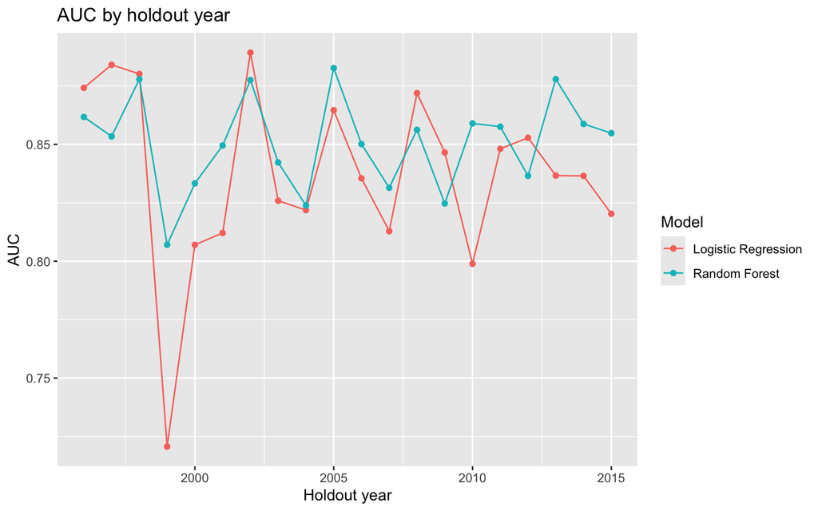

```r
auc_long <- auc_results %>%
  pivot_longer(cols = c(logistic_auc, random_forest_auc), names_to = "model", values_to = "auc") %>%
  mutate(
    model = recode(
      model,
      logistic_auc = "Logistic Regression",
      random_forest_auc = "Random Forest"
    )
  )

ggplot(auc_long, aes(x = holdout_year, y = auc, color = model)) +
  geom_line() +
  geom_point() +
  labs(
    title = "AUC by holdout year",
    x = "Holdout year",
    y = "AUC",
    color = "Model"
  )
```

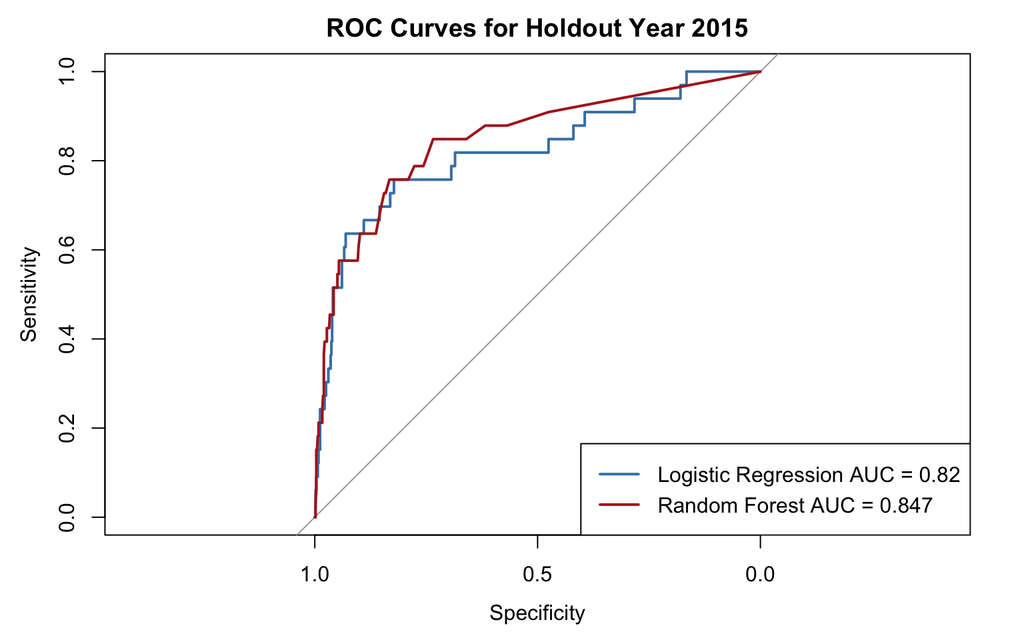

```r
final_year <- max(holdout_years)

train_df <- model_df %>% filter(year < final_year)
test_df <- model_df %>% filter(year == final_year)

log_fit_final <- glm(predictor_formula, data = train_df, family = binomial)
log_prob_final <- predict(log_fit_final, newdata = test_df, type = "response")

train_rf <- train_df %>% mutate(any_notable_f = factor(any_notable, levels = c(0, 1)))
test_rf <- test_df %>% mutate(any_notable_f = factor(any_notable, levels = c(0, 1)))

rf_formula <- any_notable_f ~
  lag_any_1 + lag_any_2 + lag_any_3 + lag_any_12 +
  lag_notable_1 + lag_notable_12 +
  lag_total_1 + lag_total_12 +
  roll_notable_3 + roll_notable_12 +
  hist_rate + lag_lightning_share_1 +
  month_sin + month_cos

rf_fit_final <- randomForest(rf_formula, data = train_rf, ntree = 300, importance = TRUE)
rf_prob_final <- predict(rf_fit_final, newdata = test_rf, type = "prob")[, "1"]

roc_log <- roc(test_df$any_notable, log_prob_final, quiet = TRUE)
roc_rf <- roc(test_df$any_notable, rf_prob_final, quiet = TRUE)

plot(roc_log, col = "steelblue", main = paste("ROC Curves for Holdout Year", final_year))
plot(roc_rf, add = TRUE, col = "firebrick")
legend(
  "bottomright",
  legend = c(
    paste0("Logistic Regression AUC = ", round(as.numeric(auc(roc_log)), 3)),
    paste0("Random Forest AUC = ", round(as.numeric(auc(roc_rf)), 3))
  ),
  col = c("steelblue", "firebrick"),
  lwd = 2
)
```

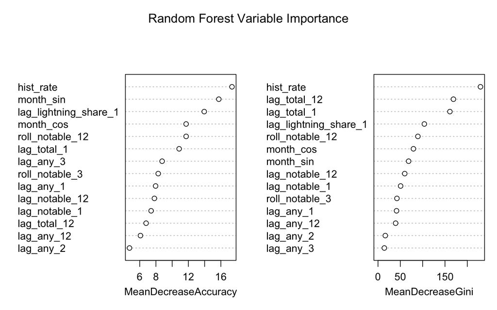

```r
varImpPlot(rf_fit_final, main = "Random Forest Variable Importance")
```

The variable importance plot helps to identify the predictors that are contributing the most to the random forest model. From the plot, it is clear that the predictors related to wildfire history and seasonality are among the most important. This aligns with the results from earlier in the exploratory data analysis. Again, this confirms the results from the earlier stages of the exploratory data analysis, as the results from the model align with the results from the EDA. This confirms that the results from the model are accurate, as they align with the results from the EDA. From the results, it is clear that the random forest model is performing well, as it is able to incorporate the history and seasonality of wildfires. From the results, it is clear that the incidence of wildfires is dependent on a combination of history and seasonality, as opposed to an isolated factor.

## 7 Conclusion

The present report sought to analyze the occurrence of wildfires in the United States by designing a state-month panel and conceptualizing the prediction problem as a binary classification problem. A wildfire was conceptualized as a notable event if the burned area was at least 300 acres, and the response variable tracked whether a state reported at least one notable wildfire for a particular month. This approach allowed the analysis to target the more significant wildfires and place the data into a framework that could be used by statistical and machine learning techniques.

The results of the exploratory analysis identified two key trends. First, the occurrence of wildfires varies significantly between states, highlighting the geographic heterogeneity of underlying wildfire risk. Second, the occurrence of wildfires demonstrates a strong seasonal effect, with many more wildfires occurring during the warmer months of the year rather than the colder months. In addition, state-months reporting notable wildfire activity were associated with increased historical wildfire rates, indicating the value of historical wildfire predictors.

Two prediction models were used for evaluation. These include a logistic regression model, which serves as a baseline model, and a random forest model, which serves as a nonlinear model. Using a time-aware rolling validation method and an AUC evaluation metric, the random forest model had a higher prediction accuracy compared to the logistic regression model. This shows that wildfire occurrence indeed depends on nonlinear relationships. However, the use of a logistic regression model still proves to be effective for understanding the prediction problem as a whole.

The results obtained from this analysis show that the historical wildfire activity, seasonality, and other environmental factors are indeed effective for use in wildfire prediction. This analysis proves that it is possible to identify a set of patterns for wildfire occurrence even with a simple state-month aggregation. The model can be further improved by incorporating other environmental factors such as weather, drought, and vegetation. However, the results obtained show that the use of wildfire history and seasonality alone for prediction purposes is effective.

GitHub repository for reproducibility: https://github.com/rohit-krishna20/STA141A-WildfireProject